# Week 3 - Homework

STAT 420, Summer 2023, D. Unger

# Directions

Students are encouraged to work together on homework. However, sharing, copying or providing any part of a homework solution or code is an infraction of the University’s rules on Academic Integrity. Any violation will be punished as severely as possible.

- Be sure to remove this section if you use this `.Rmd` file as a template.
- You may leave the questions in your final document.

## Exercise 1 (Using `lm` for Inference)

For this exercise we will use the `cats` dataset from the `MASS` package. You should use `?cats` to learn about the background of this dataset.

**(a)** Fit the following simple linear regression model in `R`. Use heart weight as the response and body weight as the predictor.

$$Y_i = \beta_0 + \beta_1 x_i + \epsilon_i$$

Store the results in a variable called `cat_model`. Use a $t$ test to test the significance of the regression. Report the following:

- The null and alternative hypotheses
- The value of the test statistic
- The p-value of the test
- A statistical decision at $\alpha = 0.05$
- A conclusion in the context of the problem

**Solution:**

```r
df_cat = MASS::cats

cat_model = lm(Hwt ~ Bwt, data = df_cat)
#summary(cat_model)

t_test = summary(cat_model)$coefficients[2,3]
p_val = summary(cat_model)$coefficients['Bwt', 'Pr(>|t|)']
```

**Hypothesis Test**

$H_0: \beta_1 = 0$ vs $H_1: \beta_1 \ne 0$

$t-Statistic$: 16.1193908

$p-value$: 6.9690446^{-34}

$\alpha = 0.05$

**Statistical Decision:** Reject the Null Hypothesis

The null hypothesis assumed no relationship between the predictor body weight (Bwt) and the response heart weight (Hwt). since the $p-value$ for this test is far below the decision level of $\alpha = 0.05$ we reject the $Null$ hypothesis and assume there is some relationship between the predictor and response variables.

When reporting these, you should explicitly state them in your document, not assume that a reader will find and interpret them from a large block of `R` output.

**(b)** Calculate a 95% confidence interval for $\beta_1$. Give an interpretation of the interval in the context of the problem.

**Solution:**

```r
ci_95 = confint(cat_model, parm = 'Bwt', level = 0.95)
ci_95
```

```
##        2.5 %   97.5 %
## Bwt 3.539343 4.528782
```

At a 95% level of confidence, the mean value of $\beta_1$ is between 3.539 and 4.529.

**(c)** Calculate a 90% confidence interval for $\beta_0$. Give an interpretation of the interval in the context of the problem.

**Solution:**

```r
ci_90 = confint(cat_model, parm = '(Intercept)', level = 0.90)
ci_90
```

```
##                   5 %      95 %
## (Intercept) -1.502834 0.7895096
```

At a 90% level of confidence, the mean value of $\beta_0$ is between -1.503 and 0.790.

**(d)** Use a 90% confidence interval to estimate the mean heart weight for body weights of 2.1 and 2.8 kilograms. Which of the two intervals is wider? Why?

**Solution:**

```r
library(tidyverse)
library(kableExtra)

# New values to model
new_wt = data.frame(Bwt = c(2.1, 2.8))

# Prediction of response based on new predictor values
pre_hwt = predict(cat_model, newdata = new_wt, interval = 'confidence', level = 0.90)

# Format a dataframe for output as a table
pre_hwt = as_tibble(pre_hwt) %>%
  bind_cols(new_wt) %>%
  relocate(Bwt) %>%
  mutate(`Interval Range` = upr - lwr) %>%
  rename('Body Weight (kg)'=  Bwt,
       'Estimated Heart Weight (g)' = fit,
       'Lower Bound (CI 90%)' = lwr,
       'Upper Bound (CI 90%)' = upr)

# Calculate the mean of the predictor variable
bwt_mean = mean(df_cat$Bwt)

# Display table
tbl = pre_hwt %>%
  kbl() %>%
  kable_styling()

tbl
```

| Body Weight (kg) | Estimated Heart Weight (g) | Lower Bound (CI 90%) | Upper Bound (CI 90%) | Interval Range |
| --- | --- | --- | --- | --- |
| 2.1 | 8.114869 | 7.787882 | 8.441856 | 0.6539740 |
| 2.8 | 10.938713 | 10.735843 | 11.141583 | 0.4057402 |

The mean of the predictor variable body weight is 2.724. The predictor value of 2.1 is farther away from the average value of the body weight than the value of 2.8 and is close to the lower bound (2) of the observed data. Since the value 2.1 is farther from the mean and close to the edge of the range of observed values, there will be fewer observed sample values around 2.1 which will then lead to increased variability in that area of body weight’s distribution. This increase in variability of the predictor will then produce a wider confidence interval in the estimate of the response variable.

**(e)** Use a 90% prediction interval to predict the heart weight for body weights of 2.8 and 4.2 kilograms.

**Solution:**

```r
# New values to model
new_pred = data.frame(Bwt = c(2.8, 4.2))

# Prediction of response based on new predictor values
pre_hwt2 = predict(cat_model, newdata = new_pred, interval = 'prediction', level = 0.90)

# Format a dataframe for output as a table
pre_hwt2 = as_tibble(pre_hwt2) %>%
  bind_cols(new_pred) %>%
  relocate(Bwt) %>%
  rename('Body Weight (kg)'=  Bwt,
         'Estimated Heart Weight (g)' = fit,
         'Lower Bound (PI 90%)' = lwr,
         'Upper Bound (PI 90%)' = upr)

# Display table
tbl2 = pre_hwt2 %>%
  kbl() %>%
  kable_styling()

tbl2
```

| Body Weight (kg) | Estimated Heart Weight (g) | Lower Bound (PI 90%) | Upper Bound (PI 90%) |
| --- | --- | --- | --- |
| 2.8 | 10.93871 | 8.525541 | 13.35189 |
| 4.2 | 16.58640 | 14.097100 | 19.07570 |

**(f)** Create a scatterplot of the data. Add the regression line, 95% confidence bands, and 95% prediction bands.

**Solution:**

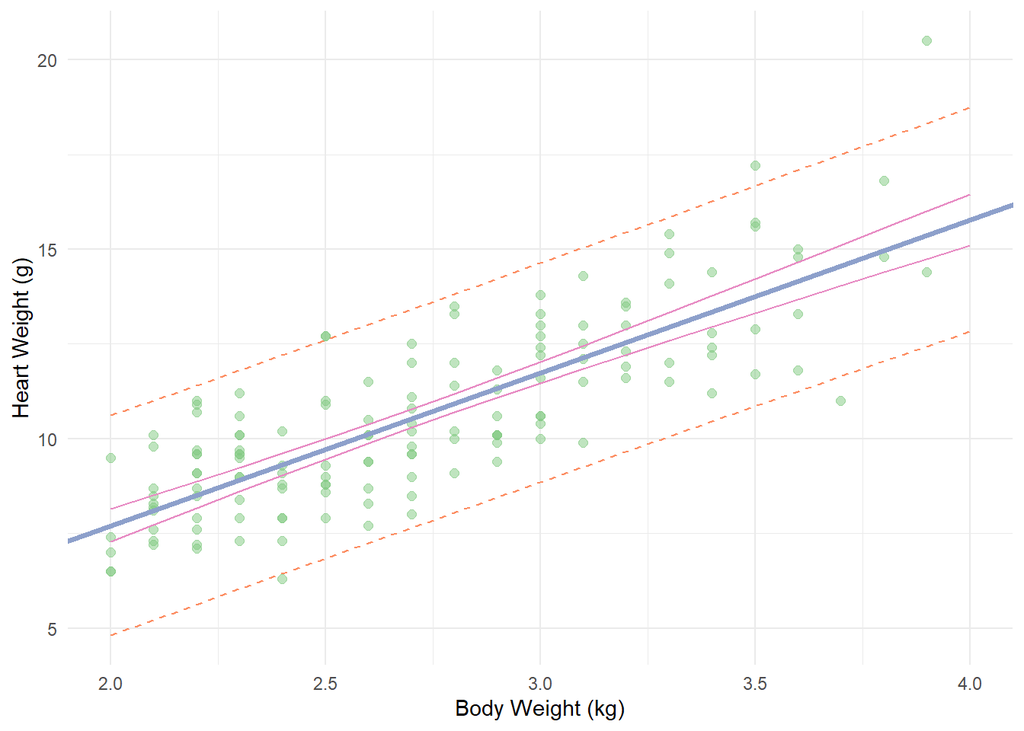

```r
# Coefficients for original model - used for regression line
cat_coef = coef(cat_model)

# Range of values within dataset
all_values = tibble(Bwt = seq(min(df_cat$Bwt), max(df_cat$Bwt) + 0.1, by = 0.1))

# Confidence and Prediction bands for scatterplot
band_conf = as.tibble(predict(cat_model, newdata = all_values, interval = 'confidence', level = 0.95)) %>% bind_cols(all_values)
band_pred = as.tibble(predict(cat_model, newdata = all_values, interval = 'prediction', level = 0.95)) %>% bind_cols(all_values)


# Scatterplot
cat_plot = ggplot(df_cat, aes(x = Bwt, y = Hwt)) +
  # Data points
  geom_point(color = '#7fc97f', fill = '#66c2a5', alpha = 0.5, size = 2) +
  # Regression line
  geom_abline(intercept = cat_coef[1], slope = cat_coef[2], color = '#8da0cb', size = 1.25) +
  # Confidence Bands
  geom_line(data = band_conf, aes(x = Bwt, y = upr), color = '#e78ac3') +
  geom_line(data = band_conf, aes(x = Bwt, y = lwr), color = '#e78ac3') +
  # Prediction Bands
  geom_line(data = band_pred, aes(x = Bwt, y = upr), color = '#fc8d62', linetype = 2) +
  geom_line(data = band_pred, aes(x = Bwt, y = lwr), color = '#fc8d62', linetype = 2) +
  # Format plot
  theme_minimal() +
  labs(x = 'Body Weight (kg)',
       y = 'Heart Weight (g)')


cat_plot
```

**(g)** Use a $t$ test to test:

- $H_0: \beta_1 = 4$
- $H_1: \beta_1 \neq 4$

Report the following:

- The value of the test statistic
- The p-value of the test
- A statistical decision at $\alpha = 0.05$

**Solution:**

```r
se = summary(cat_model)$coefficients[2,2]
beta_1 = summary(cat_model)$coefficients[2,1]

t = (beta_1 - 4) / se

p_val = pt(t, df = 144 - 2)
```

When reporting these, you should explicitly state them in your document, not assume that a reader will find and interpret them from a large block of `R` output.

## Exercise 2 (More `lm` for Inference)

For this exercise we will use the `Ozone` dataset from the `mlbench` package. You should use `?Ozone` to learn about the background of this dataset. You may need to install the `mlbench` package. If you do so, do not include code to install the package in your `R` Markdown document.

For simplicity, we will re-perform the data cleaning done in the previous homework.

```r
data(Ozone, package = "mlbench")
Ozone = Ozone[, c(4, 6, 7, 8)]
colnames(Ozone) = c("ozone", "wind", "humidity", "temp")
Ozone = Ozone[complete.cases(Ozone), ]
```

**(a)** Fit the following simple linear regression model in `R`. Use the ozone measurement as the response and wind speed as the predictor.

$$Y_i = \beta_0 + \beta_1 x_i + \epsilon_i$$

Store the results in a variable called `ozone_wind_model`. Use a $t$ test to test the significance of the regression. Report the following:

- The null and alternative hypotheses
- The value of the test statistic
- The p-value of the test
- A statistical decision at $\alpha = 0.01$
- A conclusion in the context of the problem

**Solution:**

```r
ozone_wind_model = lm(ozone ~ wind, data = Ozone)
#summary(ozone_wind_model)

# t-test and p-value for output
t_test_ow = summary(ozone_wind_model)$coefficients[2,3]
p_val_ow = summary(ozone_wind_model)$coefficients['wind', 'Pr(>|t|)']
```

**Hypothesis Test**

$H_0: \beta_1 = 0$ vs $H_1: \beta_1 \ne 0$

$t-Statistic$: -0.2189811

$p-value$: 0.8267954

$\alpha = 0.01$

**Statistical Decision:** Fail to Reject the Null Hypothesis

The null hypothesis assumes no relationship between the predictor wind speed and the response ozone measurement. since the $p-value$ for this test is well above the decision level of $\alpha = 0.01$ we fail to reject the $Null$ hypothesis and assume there is likely no relationship between wind speed and the ozone measurements.

When reporting these, you should explicitly state them in your document, not assume that a reader will find and interpret them from a large block of `R` output.

**(b)** Fit the following simple linear regression model in `R`. Use the ozone measurement as the response and temperature as the predictor.

$$Y_i = \beta_0 + \beta_1 x_i + \epsilon_i$$

Store the results in a variable called `ozone_temp_model`. Use a $t$ test to test the significance of the regression. Report the following:

- The null and alternative hypotheses
- The value of the test statistic
- The p-value of the test
- A statistical decision at $\alpha = 0.01$
- A conclusion in the context of the problem

**Solution:**

```r
ozone_temp_model = lm(ozone ~ temp, data = Ozone)
#summary(ozone_temp_model)

# t-test and p-value for output
t_test_ot = summary(ozone_temp_model)$coefficients[2,3]
p_val_ot = summary(ozone_temp_model)$coefficients['temp', 'Pr(>|t|)']
```

**Hypothesis Test**

$H_0: \beta_1 = 0$ vs $H_1: \beta_1 \ne 0$

$t-Statistic$: 22.848962

$p-value$: 8.1537636^{-71}

$\alpha = 0.01$

**Statistical Decision:** Reject the Null Hypothesis

The null hypothesis assumes no relationship between the predictor temperature and the response ozone measurement. since the $p-value$ for this test is below the decision level of $\alpha = 0.01$ we reject the $Null$ hypothesis and assume there is likely a relationship between temperature and the ozone measurements.

When reporting these, you should explicitly state them in your document, not assume that a reader will find and interpret them from a large block of `R` output.

## Exercise 3 (Simulating Sampling Distributions)

For this exercise we will simulate data from the following model:

$$Y_i = \beta_0 + \beta_1 x_i + \epsilon_i$$

Where $\epsilon_i \sim N(0, \sigma^2).$ Also, the parameters are known to be:

- $\beta_0 = -5$
- $\beta_1 = 3.25$
- $\sigma^2 = 16$

We will use samples of size $n = 50$.

**(a)** Simulate this model $2000$ times. Each time use `lm()` to fit a simple linear regression model, then store the value of $\hat{\beta}_0$ and $\hat{\beta}_1$. Set a seed using **your** birthday before performing the simulation. Note, we are simulating the $x$ values once, and then they remain fixed for the remainder of the exercise.

**Solution:**

```r
birthday = 19790221
set.seed(birthday)
n = 50
x = seq(0, 10, length = n)

# Parameters of model
beta0 = -5
beta1 = 3.25
s2 = 16

#Example function from text book
sim_slr = function(x, beta_0 = -5, beta_1 = 3.25, sigma = 4) {
  n = length(x)
  epsilon = rnorm(n, mean = 0, sd = sigma)
  y = beta_0 + beta_1 * x + epsilon
  data.frame(predictor = x, response = y)
}


# Instantiate vector to hold slope and intercept
df_sim = tibble(beta_hat_0 = rep(0, 2000),
                beta_hat_1 = rep(0, 2000))


# Simulation
for(i in 1:2000){
  # Generate data
  my_sim = sim_slr(x)
  # Fit model with generated data
  my_sim_fit = lm(response ~ predictor, data = my_sim)
  # Get betas
  intercept = summary(my_sim_fit)$coefficients[1, 1]
  slope = summary(my_sim_fit)$coefficients[2, 1]

  df_sim$beta_hat_0[i] = intercept
  df_sim$beta_hat_1[i] = slope
}
```

**(b)** Create a table that summarizes the results of the simulations. The table should have two columns, one for $\hat{\beta}_0$ and one for $\hat{\beta}_1$. The table should have four rows:

- A row for the true expected value given the known values of $x$
- A row for the mean of the simulated values
- A row for the true standard deviation given the known values of $x$
- A row for the standard deviation of the simulated values

**Solution:**

```r
# Calculate Variance distribution for betas
Sxx = sum((x - mean(x)) ^ 2)
var_beta_hat_0 = s2 * (1 / n + mean(x) ^ 2 / Sxx)
var_beta_hat_1 = s2 / Sxx


# table for output display
df_out = tibble(Metric = c('True Expected Value',
                           'Mean of Simulated Values',
                           'True Standard Deviation',
                           'Standard Deviation of Simulated Values'),
                beta_hat_0 = c(-5,
                               mean(df_sim$beta_hat_0),
                               sqrt(var_beta_hat_0),
                               sd(df_sim$beta_hat_0)),
                beta_hat_1 = c(3.25,
                               mean(df_sim$beta_hat_1),
                               sqrt(var_beta_hat_1),
                               sd(df_sim$beta_hat_1)))

# Add latex to column names
names(df_out) =  c("Metric", "$\\hat\\beta_0$", "$\\hat\\beta_1$")

# Table for displaying results
tbl = df_out %>%
  kbl() %>%
  kable_styling()

tbl
```

| Metric | $\hat\beta_0$ | $\hat\beta_1$ |
| --- | --- | --- |
| True Expected Value | -5.000000 | 3.2500000 |
| Mean of Simulated Values | -5.005916 | 3.2528911 |
| True Standard Deviation | 1.114609 | 0.1920784 |
| Standard Deviation of Simulated Values | 1.128051 | 0.1986343 |

**(c)** Plot two histograms side-by-side:

- A histogram of your simulated values for $\hat{\beta}_0$. Add the normal curve for the true sampling distribution of $\hat{\beta}_0$.
- A histogram of your simulated values for $\hat{\beta}_1$. Add the normal curve for the true sampling distribution of $\hat{\beta}_1$.

**Solution:**

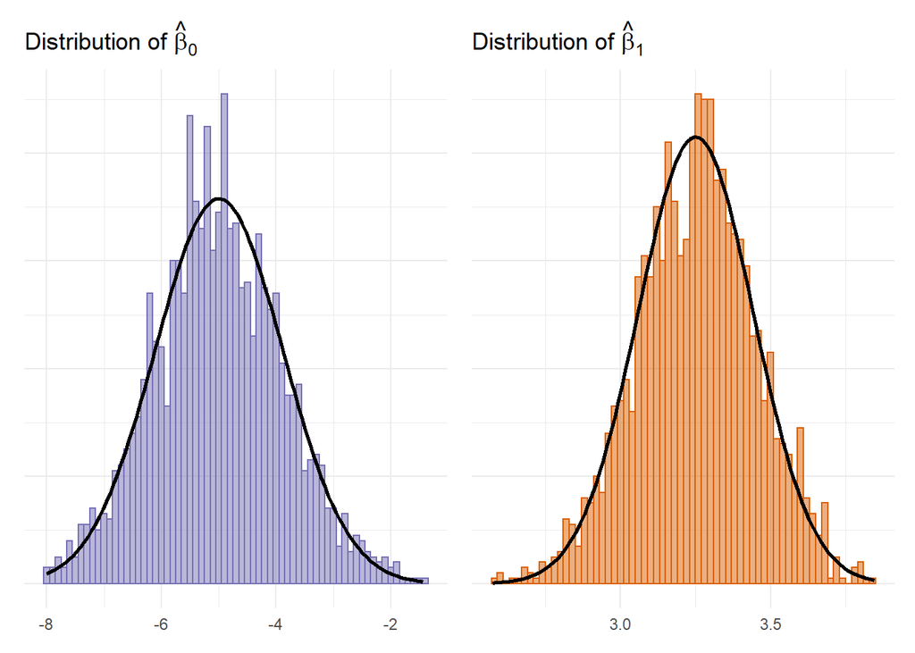

```r
library(patchwork)
library(latex2exp)

hist_beta_0 = ggplot(df_sim, aes(x = beta_hat_0)) +
  geom_histogram(aes(y = ..density..), binwidth = 0.1, fill = "#7570b3", color = "#7570b3", alpha = 0.5) +
  geom_function(fun = dnorm, args = list(mean = beta0, sd = sqrt(var_beta_hat_0)), size = 1) +
  theme_minimal() +
  theme(axis.text.y = element_blank()) +
  labs(x = NULL,
       y = NULL,
       title = TeX(r'(Distribution of $\hat{\beta}_0$)'))

#hist_beta_0

hist_beta_1 = ggplot(df_sim, aes(x = beta_hat_1)) +
  geom_histogram(aes(y = ..density..), binwidth = 0.02, fill = "#d95f02", color = "#d95f02", alpha = 0.5) +
  geom_function(fun = dnorm, args = list(mean = beta1, sd = sqrt(var_beta_hat_1)), size = 1) +
  theme_minimal() +
  theme(axis.text.y = element_blank()) +
  labs(x = NULL,
       y = NULL,
       title = TeX(r'(Distribution of $\hat{\beta}_1$)'))

#hist_beta_1

p_final = hist_beta_0 + hist_beta_1

p_final
```

## Exercise 4 (Simulating Confidence Intervals)

For this exercise we will simulate data from the following model:

$$Y_i = \beta_0 + \beta_1 x_i + \epsilon_i$$

Where $\epsilon_i \sim N(0, \sigma^2).$ Also, the parameters are known to be:

- $\beta_0 = 5$
- $\beta_1 = 2$
- $\sigma^2 = 9$

We will use samples of size $n = 25$.

Our goal here is to use simulation to verify that the confidence intervals really do have their stated confidence level. Do **not** use the `confint()` function for this entire exercise.

**(a)** Simulate this model $2500$ times. Each time use `lm()` to fit a simple linear regression model, then store the value of $\hat{\beta}_1$ and $s_e$. Set a seed using **your** birthday before performing the simulation. Note, we are simulating the $x$ values once, and then they remain fixed for the remainder of the exercise.

**Solution:**

```r
birthday = 19790221
set.seed(birthday)
n = 25
x = seq(0, 2.5, length = n)


#Example function from text book
sim_slr = function(x, beta_0 =5, beta_1 = 2, sigma = 3) {
  n = length(x)
  epsilon = rnorm(n, mean = 0, sd = sigma)
  y = beta_0 + beta_1 * x + epsilon
  data.frame(predictor = x, response = y)
}


# vector to hold slope and standard error
df_sim = tibble(beta_hat_1 = rep(0, 2500),
                s_e = rep(0, 2500))


# Simulation
for(i in 1:2500){
  # Generate data
  my_sim = sim_slr(x)
  # Fit model with generated data
  my_sim_fit = lm(response ~ predictor, data = my_sim)
  # Get beta_1 and standard error
  slope = summary(my_sim_fit)$coefficients[2, 1]
  se = summary(my_sim_fit)$coefficients[2, 2]

  df_sim$beta_hat_1[i] = slope
  df_sim$s_e[i] = se

}
```

**(b)** For each of the $\hat{\beta}_1$ that you simulated, calculate a 95% confidence interval. Store the lower limits in a vector `lower_95` and the upper limits in a vector `upper_95`. Some hints:

- You will need to use `qt()` to calculate the critical value, which will be the same for each interval.
- Remember that `x` is fixed, so $S_{xx}$ will be the same for each interval.
- You could, but do not need to write a `for` loop. Remember vectorized operations.

**Solution:**

```r
# Get critical value for t-distribution
alpha = 1 - ((1 - .95) / 2)
critical_value = qt(alpha, df = length(x) - 2)

# Calculate upper and lower limits
df_sim = df_sim %>%
  mutate(lower_95 = beta_hat_1 - critical_value * s_e,
         upper_95 = beta_hat_1 + critical_value * s_e)
```

**(c)** What proportion of these intervals contains the true value of $\beta_1$?

**Solution:**

```r
df_sim = df_sim %>%
  mutate(contains_true_value = if_else(lower_95 <= 2 &
                                         upper_95 >= 2, 1, 0))

prop_int = mean(df_sim$contains_true_value)
```

94.36% of simulated intervals contain the true value of $\beta_1$.

**(d)** Based on these intervals, what proportion of the simulations would reject the test $H_0: \beta_1 = 0$ vs $H_1: \beta_1 \neq 0$ at $\alpha = 0.05$?

**Solution:**

```r
df_sim = df_sim %>%
  mutate(reject_null_hyp = if_else(lower_95 <= 0 &
                                         upper_95 >= 0, 1, 0))

reject = mean(df_sim$reject_null_hyp)
```

**(e)** For each of the $\hat{\beta}_1$ that you simulated, calculate a 99% confidence interval. Store the lower limits in a vector `lower_99` and the upper limits in a vector `upper_99`.

**Solution:**

```r
# Get critical value for t-distribution
alpha = 1 - ((1 - .99) / 2)
critical_value = qt(alpha, df = length(x) - 2)

# Calculate upper and lower limits
df_sim = df_sim %>%
  mutate(lower_99 = beta_hat_1 - critical_value * s_e,
         upper_99 = beta_hat_1 + critical_value * s_e)
```

**(f)** What proportion of these intervals contains the true value of $\beta_1$?

**Solution:**

```r
df_sim = df_sim %>%
  mutate(contains_true_value_99 = if_else(lower_99 <= 2 &
                                         upper_99 >= 2, 1, 0))

prop_int_99 = mean(df_sim$contains_true_value_99)
```

98.80% of the 99% confidence intervals contain the true value of $\beta_1$.

**(g)** Based on these intervals, what proportion of the simulations would reject the test $H_0: \beta_1 = 0$ vs $H_1: \beta_1 \neq 0$ at $\alpha = 0.01$?

**Solution:**

```r
df_sim = df_sim %>%
  mutate(reject_null_hyp_99 = if_else(lower_99 <= 0 &
                                         upper_99 >= 0, 1, 0))

reject = mean(df_sim$reject_null_hyp_99)
```

## Exercise 5 (Prediction Intervals “without” `predict`)

Write a function named `calc_pred_int` that performs calculates prediction intervals:

$$\hat{y}(x) \pm t_{\alpha/2, n - 2} \cdot s_e\sqrt{1 + \frac{1}{n}+\frac{(x-\bar{x})^2}{S_{xx}}}.$$

for the linear model

$$Y_i = \beta_0 + \beta_1 x_i + \epsilon_i.$$

**(a)** Write this function. You may use the `predict()` function, but you may **not** supply a value for the `level` argument of `predict()`. (You can certainly use `predict()` any way you would like in order to check your work.)

The function should take three inputs:

- `model`, a model object that is the result of fitting the SLR model with `lm()`
- `newdata`, a data frame with a single observation (row)
  - This data frame will need to have a variable (column) with the same name as the data used to fit `model`.
- `level`, the level (0.90, 0.95, etc) for the interval with a default value of `0.95`

The function should return a named vector with three elements:

- `estimate`, the midpoint of the interval
- `lower`, the lower bound of the interval
- `upper`, the upper bound of the interval

**Solultion:**

```r
calc_pred_int = function(model, newdata, level = 0.95){

  # Components of the prediction interval calculation
  # Get critical value for t-distribution
  alpha = 1 - ((1 - level) / 2)
  critical_value = qt(alpha, df = length(model$model[[2]]) - 2)

  # standard error of residuals
  se = sd(model$residuals)

  # number of observations (sample size)
  n = length(model$model[[2]])

  # x and mean x
  x = newdata[1,1]
  mean_x = mean(model$model[[2]], na.rm = TRUE)

  # Sxx
  sxx = sum((model$model[[2]] - mean_x) ^ 2)

  # Point estimate y_hat
  # Get betas
  intercept = summary(model)$coefficients[1, 1]
  slope = summary(model)$coefficients[2, 1]

  estimate = intercept + slope * x


  # Begin calculation of prediction bound
  prediction_bound = critical_value * se * sqrt(1 + (1 / n) + ((x - mean_x)^2  / sxx))

  # Upper and lower bounds of interval
  lower = estimate - prediction_bound
  upper = estimate + prediction_bound

  output = c('estimate' = estimate,
             'lower' = lower,
             'upper' = upper)

  return(output)
}
```

**(b)** After writing the function, run this code:

```r
newcat_1 = data.frame(Bwt = 4.0)
calc_pred_int(cat_model, newcat_1)
```

[output not shown]

**(c)** After writing the function, run this code:

```r
newcat_2 = data.frame(Bwt = 3.3)
calc_pred_int(cat_model, newcat_2, level = 0.90)
```

[output not shown]